# Lab 5

#### Marginal Distributions

Another variation of the scatterplot involves adding visualizations of the marginal distributions of the X and Y variables. This can be via histograms, boxplots, or density curves. Here is a version of our initial scatterplot, area vs. population, with marginal histograms added:

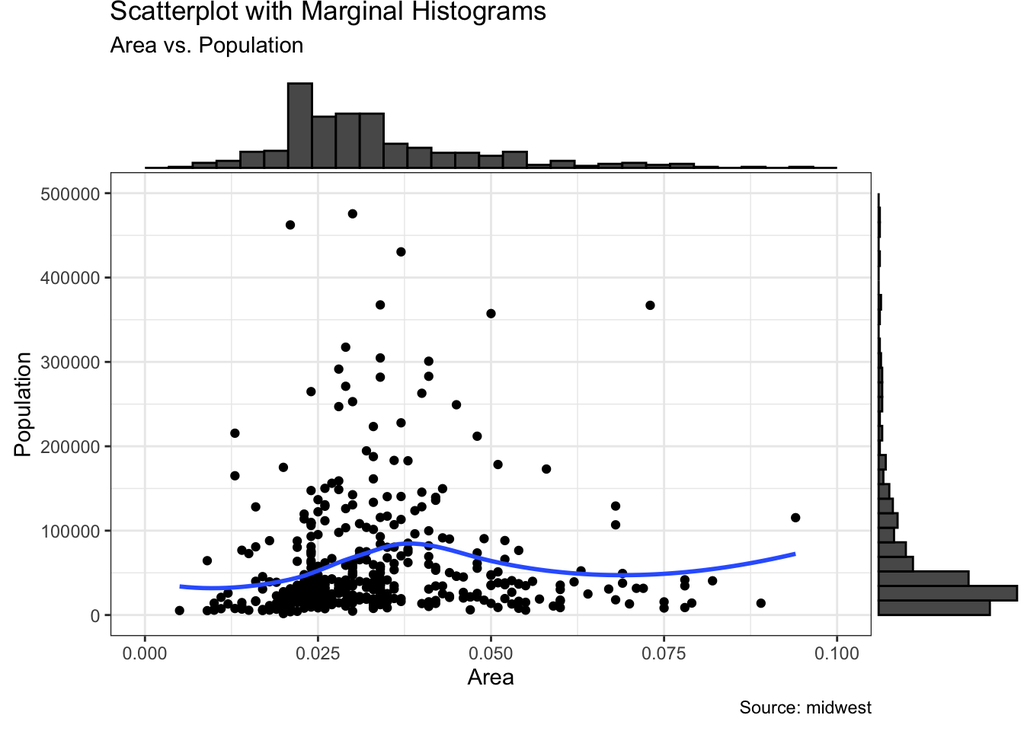

```r
gg <- ggplot(midwest, aes(x = area, y = poptotal)) +
  geom_point() +
  geom_smooth(method = "loess", se = F) +
  xlim(c(0, 0.1)) +
  ylim(c(0, 500000)) +
  labs(subtitle = "Area vs. Population",
       y = "Population",
       x = "Area",
       title = "Scatterplot with Marginal Histograms",
       caption = "Source: midwest")

ggMarginal(gg, type = "histogram")
```

Or with marginal boxplots:

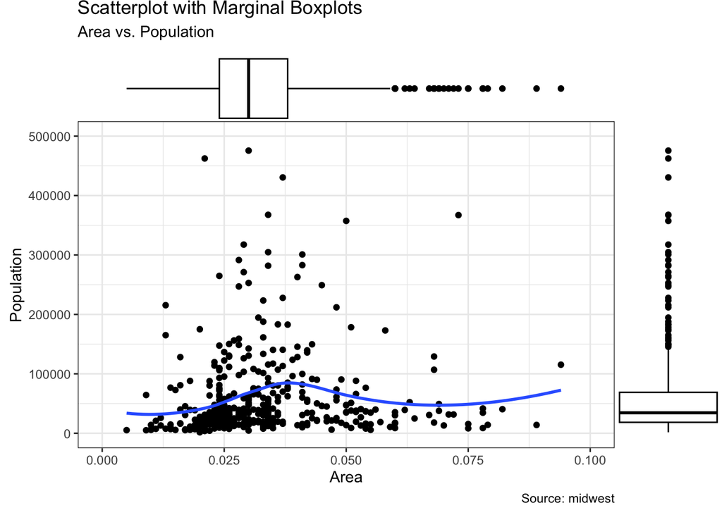

```r
gg <- ggplot(midwest, aes(x = area, y = poptotal)) +
  geom_point() +
  geom_smooth(method = "loess", se = F) +
  xlim(c(0, 0.1)) +
  ylim(c(0, 500000)) +
  labs(subtitle = "Area vs. Population",
       y = "Population",
       x = "Area",
       title = "Scatterplot with Marginal Boxplots",
       caption = "Source: midwest")

ggMarginal(gg, type = "boxplot")
```

These types of plots are useful when you want to visualize both the bivariate and univariate relationships at the same time.

### Correlogram

A correlogram is a visualization used to display the correlation between multiple continuous variables in a dataset. It’s typically presented as a color-coded matrix, where the colors indicate the strength and direction of the relationship, varying from strong negative (cool colors, typically) to strong positive (warm colors typically). The diagonal of the matrix is usually the correlation of each variable with itself (which is always $1$). Often people only display either the upper or lower triangle of the matrix; the other triangle has redundant information, and presenting too much information at once can overwhelm the viewer.

For this we’ll introduce the `mtcars` data. We would continue using `mpg`, but that dataset has a lot of categorical variables, whereas `mtcars` has a variety of continuous ones.

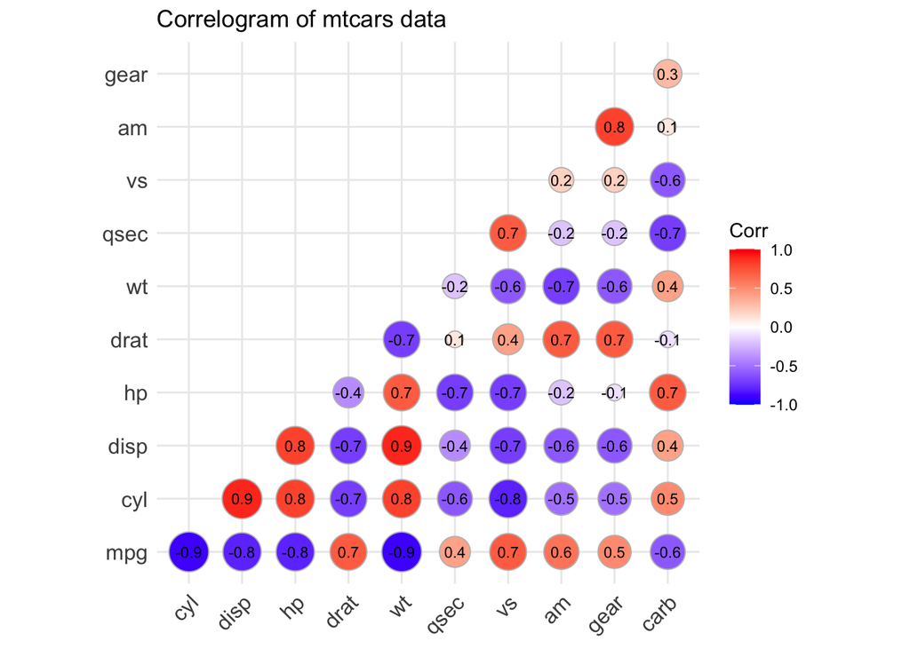

```r
data("mtcars")
corr <- round(cor(mtcars), 1)

ggcorrplot(corr,
           type = "lower",
           lab = TRUE,
           lab_size = 3,
           method = "circle",
           title = "Correlogram of mtcars data")
```

## Exercises

For this lab, you will create some visualizations using the `penguins` data. The following code displays the first few rows of the data in R.

```r
penguins %>%
  head()
```

```
# A tibble: 6 × 8
  species island    bill_length_mm bill_depth_mm flipper_length_mm body_mass_g
  <fct>   <fct>              <dbl>         <dbl>             <int>       <int>
1 Adelie  Torgersen           39.1          18.7               181        3750
2 Adelie  Torgersen           39.5          17.4               186        3800
3 Adelie  Torgersen           40.3          18                 195        3250
4 Adelie  Torgersen           NA            NA                  NA          NA
5 Adelie  Torgersen           36.7          19.3               193        3450
6 Adelie  Torgersen           39.3          20.6               190        3650
# ℹ 2 more variables: sex <fct>, year <int>
```

1. Create a histogram of penguin body mass in grams.
2. Create a density curve of penguin body mass in grams.
3. Create box plots of body mass in grams by penguin species.
4. Create density curves of body mass in grams by penguin species.
5. Create a percent stacked bar chart displaying the species of penguins on each island.
6. Create a scatterplot with body mass on the y-axis and flipper length on the x-axis. Color-code the points by penguin species. Add marginal histograms.
7. Create a correlogram of the continuous variables in the penguin dataset.